# HW3

```python
import os
import sys
import glob
import pandas as pd
import numpy as np
import warnings
```

```python
warnings.filterwarnings("ignore")
os.chdir('C:/Users/Ozan Ozturk/Desktop/Files/HW3/data')
files=glob.glob('*')

df = pd.read_csv(files[0])
df = df.iloc[::-1].reset_index(drop=True)
```

Lets modify the dataframe

```python
df['Date']=pd.to_datetime(df['Date'])
df['Consumption (MWh)']=df['Consumption (MWh)'].apply(lambda x: x.replace(',','')).astype(float)
```

Lets define some functions

```python
def train_test_split(df,date):
    train=df.loc[df['Date'] < date]
    test=df.loc[df['Date'] >= date]
    return train, test

def shift_series(x,n):
    return x.shift(-n).dropna().reset_index(drop=True).rename('lag '+str(n))

def long_format(df,lag1,lag2):
    x=df['Consumption (MWh)']
    return pd.concat([df,shift_series(x,lag1),shift_series(x,(lag2))], axis=1).dropna()
```

```python
long_df=long_format(df,48,168)

long_df
```

|  | Date | Hour | Consumption (MWh) | lag 48 | lag 168 |
| --- | --- | --- | --- | --- | --- |
| 0 | 2020-01-12 | 23:00 | 35725.46 | 32295.74 | 36186.83 |
| 1 | 2020-01-12 | 22:00 | 37173.97 | 33698.14 | 37446.73 |
| 2 | 2020-01-12 | 21:00 | 38310.79 | 34491.45 | 38366.41 |
| 3 | 2020-01-12 | 20:00 | 39195.74 | 35383.08 | 39240.65 |
| 4 | 2020-01-12 | 19:00 | 40720.16 | 36310.77 | 40895.17 |
| ... | ... | ... | ... | ... | ... |
| 42955 | 2016-08-01 | 04:00 | 25128.15 | 25864.63 | 22002.91 |
| 42956 | 2016-08-01 | 03:00 | 25315.55 | 25719.19 | 22464.78 |
| 42957 | 2016-08-01 | 02:00 | 25975.34 | 26578.97 | 23532.61 |
| 42958 | 2016-08-01 | 01:00 | 27112.37 | 27614.02 | 24991.82 |
| 42959 | 2016-08-01 | 00:00 | 28602.02 | 29189.27 | 26277.24 |

42960 rows × 5 columns

Because of day light change there is a discripincy in data. Therefore we remove all related parts from dataframe

```python
long_df.drop(long_df[long_df['Consumption (MWh)']==0].index,inplace=True)
long_df.drop(long_df[long_df['lag 48']==0].index,inplace=True)
long_df.drop(long_df[long_df['lag 168']==0].index,inplace=True)
```

## Task A

```python
def MAPE(y_true,y_predicted):
    return np.mean(np.abs((y_true - y_predicted)/y_true))*100

def MAPE_table(test):
    mape_lag48=MAPE( test['Consumption (MWh)'],test['lag 48'])
    mape_lag168=MAPE( test['Consumption (MWh)'],test['lag 168'])
    return pd.DataFrame(([mape_lag48,mape_lag168]),index=['lag48','lag168'],columns=['MAPE'])

date='2020-11-01'
train, test = train_test_split(long_df,date)
mape_table=MAPE_table(test)

mape_table
```

|  | MAPE |
| --- | --- |
| lag48 | 8.532919 |
| lag168 | 3.789161 |

```python
## Task B
```

```python
import statsmodels.api as sm

def modify_exog(df):
    exog = df[['lag 48','lag 168']]
    exog = sm.add_constant(exog)
    return exog

def fit_predict_linear_reg(train,test,output='all',show=True):
    exog = modify_exog(train)
    endog = train['Consumption (MWh)']
    model=sm.OLS(endog,exog,hasconst=True).fit()
    exog_test = modify_exog(test)
    summary = model.summary()
    predict = model.predict(exog_test)
    mape = MAPE(test['Consumption (MWh)'],predict)
    if show==True:
        print(summary)
    if output=='predict':
        return predict
    if output=='mape':
        return mape
    else:
        return predict,mape

def modify_table(mape_table,new_mape):
    new_mape=pd.Series({'MAPE':new_mape},name='linear regression')
    return mape_table.append(new_mape)
```

```python
predict,mape=fit_predict_linear_reg(train,test)
modify_table(mape_table,mape)
```

```
                            OLS Regression Results
==============================================================================
Dep. Variable:      Consumption (MWh)   R-squared:                       0.775
Model:                            OLS   Adj. R-squared:                  0.775
Method:                 Least Squares   F-statistic:                 7.216e+04
Date:                Fri, 08 Jan 2021   Prob (F-statistic):               0.00
Time:                        16:02:47   Log-Likelihood:            -3.8623e+05
No. Observations:               41997   AIC:                         7.725e+05
Df Residuals:                   41994   BIC:                         7.725e+05
Df Model:                           2
Covariance Type:            nonrobust
==============================================================================
                 coef    std err          t      P>|t|      [0.025      0.975]
------------------------------------------------------------------------------
const       1616.2269     83.817     19.283      0.000    1451.944    1780.510
lag 48         0.3089      0.003     99.663      0.000       0.303       0.315
lag 168        0.6420      0.003    207.631      0.000       0.636       0.648
==============================================================================
Omnibus:                     6620.473   Durbin-Watson:                   0.030
Prob(Omnibus):                  0.000   Jarque-Bera (JB):            93691.152
Skew:                          -0.299   Prob(JB):                         0.00
Kurtosis:                      10.293   Cond. No.                     3.36e+05
==============================================================================

Warnings:
[1] Standard Errors assume that the covariance matrix of the errors is correctly specified.
[2] The condition number is large, 3.36e+05. This might indicate that there are
strong multicollinearity or other numerical problems.
```

|  | MAPE |
| --- | --- |
| lag48 | 8.532919 |
| lag168 | 3.789161 |
| linear regression | 4.761000 |

## Task C

```python
def groupby_hours(df,hours):
    return {hour:df[df['Hour']==hour] for hour in hours}

def train_test_split_dict(dic,date):
    return {k:(train_test_split(v,date)) for k,v in dic.items()}

def apply_fit_predict_dict(df,hours,date):
    hour_dic=groupby_hours(df,hours)
    t_t=train_test_split_dict(hour_dic,date)
    return {k:(fit_predict_linear_reg(v[0],v[1],output='mape',show=False)) for k,v in t_t.items()}

hours=long_df['Hour'].unique()
mape_reg_wrt_hours=apply_fit_predict_dict(long_df,hours,date)


mape_reg_table=pd.DataFrame.from_dict(mape_reg_wrt_hours,orient='index',columns=['MAPE'])
```

```python
mape_reg_table
```

|  | MAPE |
| --- | --- |
| 23:00 | 3.464165 |
| 22:00 | 3.372424 |
| 21:00 | 3.229446 |
| 20:00 | 3.170657 |
| 19:00 | 3.690969 |
| 18:00 | 4.117800 |
| 17:00 | 5.202400 |
| 16:00 | 6.073473 |
| 15:00 | 6.993171 |
| 14:00 | 7.402659 |
| 13:00 | 7.331555 |
| 12:00 | 7.264094 |
| 11:00 | 7.242470 |
| 10:00 | 6.999966 |
| 09:00 | 6.367814 |
| 08:00 | 5.239575 |
| 07:00 | 4.270415 |
| 06:00 | 3.873760 |
| 05:00 | 3.812921 |
| 04:00 | 3.850653 |
| 03:00 | 3.724155 |
| 02:00 | 3.880706 |
| 01:00 | 3.727683 |
| 00:00 | 3.634741 |

## Task D

```python
def list_to_df(list1,idx_list,col_list):
    df=pd.concat(list1,axis=1).T
    df.index=idx_list
    df.index.name='Date'
    df.columns=col_list
    df.reset_index()
    return df

def wide_format(df,day1,day2):
    dates=pd.Series(df['Date'].unique().astype('datetime64[D]'))
    hours=pd.Series(df['Hour'].unique())
    list1=[]
    list2=[]
    idx_list=[]
    for i in range(len(dates)):
        try:
            a=df[(df['Date']==shift_series(dates,day1)[i])|
                (df['Date']==shift_series(dates,day2)[i])]
            a.reset_index(drop=True,inplace=True)
            list1.append(a['Consumption (MWh)'])

            b=df[df['Date']==dates[i]]
            b.reset_index(drop=True,inplace=True)
            list2.append(b['Consumption (MWh)'])

            idx_list.append(dates[i])
        except:
            break

    col_list=['lag_day'+str(d)+'_hour_'+str(i) for d in [day1,day2] for i in range(24)]

    df1=list_to_df(list1,idx_list,col_list)

    col_list=['Consumption_'+str(i) for i in range(24)]

    df2=list_to_df(list2,idx_list,col_list)

    dic={'Consumption_'+str(i):pd.concat([df1,df2[df2.columns[i]]],axis=1).reset_index() for i in range(24)}

    def drop_rows_contain_zeros(df):
        return df[(df != 0).all(1)].reset_index(drop=True)

    def apply_drop_rows_to_dic(dic):
        return {k:drop_rows_contain_zeros(v) for k,v in dic.items()}

    return apply_drop_rows_to_dic(dic)


wide_dict=wide_format(df,2,7)

wide_dict['Consumption_0']
```

|  | Date | lag_day2_hour_0 | lag_day2_hour_1 | lag_day2_hour_2 | lag_day2_hour_3 | lag_day2_hour_4 | lag_day2_hour_5 | lag_day2_hour_6 | lag_day2_hour_7 | lag_day2_hour_8 | ... | lag_day7_hour_15 | lag_day7_hour_16 | lag_day7_hour_17 | lag_day7_hour_18 | lag_day7_hour_19 | lag_day7_hour_20 | lag_day7_hour_21 | lag_day7_hour_22 | lag_day7_hour_23 | Consumption_0 |
| --- | --- | --- | --- | --- | --- | --- | --- | --- | --- | --- | --- | --- | --- | --- | --- | --- | --- | --- | --- | --- | --- |
| 0 | 2020-01-12 | 32295.74 | 33698.14 | 34491.45 | 35383.08 | 36310.77 | 36984.04 | 35411.15 | 32342.53 | 30568.06 | ... | 35946.87 | 32239.30 | 30934.51 | 29873.42 | 29650.85 | 29844.10 | 30513.78 | 31518.27 | 33520.81 | 35725.46 |
| 1 | 2020-11-30 | 34500.14 | 36016.67 | 37128.89 | 38044.69 | 39037.18 | 40203.21 | 39131.92 | 36905.20 | 35645.57 | ... | 35068.99 | 30989.04 | 28747.47 | 27754.59 | 27238.99 | 27599.20 | 28176.27 | 29097.77 | 30426.00 | 35775.04 |
| 2 | 2020-11-29 | 36119.57 | 37356.91 | 38446.22 | 39426.67 | 40806.68 | 42003.77 | 41895.73 | 39543.01 | 37760.66 | ... | 26905.24 | 27439.05 | 27737.26 | 27566.19 | 27651.60 | 28072.20 | 28703.45 | 30105.78 | 31685.68 | 32295.74 |
| 3 | 2020-11-28 | 36156.08 | 37607.20 | 38511.88 | 39520.36 | 40834.67 | 42312.06 | 42347.17 | 40532.72 | 39460.82 | ... | 32613.91 | 30564.89 | 30186.14 | 29748.05 | 29425.40 | 29828.03 | 30692.47 | 31916.72 | 33697.36 | 34500.14 |
| 4 | 2020-11-27 | 36160.62 | 37519.53 | 38420.42 | 39591.41 | 41146.25 | 42412.80 | 42837.79 | 41279.40 | 40330.14 | ... | 36386.47 | 32370.10 | 30758.76 | 29951.31 | 29795.53 | 29991.21 | 30832.30 | 31949.53 | 33651.81 | 36119.57 |
| ... | ... | ... | ... | ... | ... | ... | ... | ... | ... | ... | ... | ... | ... | ... | ... | ... | ... | ... | ... | ... | ... |
| 1783 | 2016-12-01 | 28857.66 | 30537.75 | 30462.79 | 30870.26 | 31305.87 | 31706.26 | 32006.15 | 30569.07 | 29447.75 | ... | 33106.00 | 28570.22 | 27109.29 | 26318.48 | 25975.07 | 25870.23 | 26335.78 | 27637.23 | 29244.38 | 30906.87 |
| 1784 | 2016-11-01 | 30760.17 | 32176.63 | 32097.79 | 32624.31 | 33494.32 | 34407.27 | 35045.14 | 33655.89 | 32951.39 | ... | 32982.07 | 27455.39 | 25708.59 | 24418.47 | 23860.63 | 23961.03 | 24395.07 | 25439.84 | 27103.09 | 31147.83 |
| 1785 | 2016-10-01 | 32021.60 | 33220.16 | 33048.69 | 33907.65 | 34710.46 | 35930.69 | 37773.70 | 37031.72 | 36190.41 | ... | 24638.72 | 23405.11 | 23827.08 | 23672.32 | 23511.38 | 23878.42 | 24566.31 | 25779.28 | 27613.96 | 28857.66 |
| 1786 | 2016-09-01 | 31092.87 | 32739.98 | 32638.14 | 33784.72 | 34621.65 | 35841.62 | 37906.99 | 37668.65 | 37100.43 | ... | 26930.48 | 24022.70 | 23604.98 | 23325.63 | 22870.89 | 22921.29 | 23771.58 | 24708.58 | 26224.60 | 30760.17 |
| 1787 | 2016-08-01 | 31450.65 | 32913.06 | 32931.12 | 33670.00 | 34499.94 | 35832.00 | 37304.52 | 37581.09 | 36433.88 | ... | 23094.73 | 21844.16 | 22203.54 | 21957.08 | 22002.91 | 22464.78 | 23532.61 | 24991.82 | 26277.24 | 32021.60 |

1788 rows × 50 columns

```python
from sklearn.linear_model import LassoCV

dic=train_test_split_dict(wide_dict,date)

mape_dict={}
feature_dict={}
for k,v in dic.items():
    x=v[0].iloc[:,1:-1]
    y=v[0].iloc[:,-1]
    x_test=v[1].iloc[:,1:-1]
    y_test=v[1].iloc[:,-1]

    model=LassoCV(cv=10,max_iter=10000,random_state=0)
    model_fit=model.fit(x,y)

    coef=np.abs(model_fit.coef_)
    features=pd.DataFrame(coef,index=x.columns)
    features=list(features[features[0]!=0].index)
    predict=model_fit.predict(x_test)
    mape=MAPE(predict,y_test)

    mape_dict.update({k:mape})
    feature_dict.update({k:features})
```

```python
pd.DataFrame.from_dict(feature_dict,orient='index')
```

|  | 0 | 1 | 2 | 3 | 4 | 5 | 6 | 7 | 8 | 9 | ... | 21 | 22 | 23 | 24 | 25 | 26 | 27 | 28 | 29 | 30 |
| --- | --- | --- | --- | --- | --- | --- | --- | --- | --- | --- | --- | --- | --- | --- | --- | --- | --- | --- | --- | --- | --- |
| Consumption_0 | lag_day2_hour_0 | lag_day2_hour_2 | lag_day2_hour_5 | lag_day2_hour_6 | lag_day2_hour_9 | lag_day2_hour_10 | lag_day2_hour_11 | lag_day2_hour_12 | lag_day2_hour_14 | lag_day2_hour_16 | ... | lag_day7_hour_7 | lag_day7_hour_8 | lag_day7_hour_9 | lag_day7_hour_12 | lag_day7_hour_15 | lag_day7_hour_16 | lag_day7_hour_18 | None | None | None |
| Consumption_1 | lag_day2_hour_0 | lag_day2_hour_2 | lag_day2_hour_5 | lag_day2_hour_6 | lag_day2_hour_9 | lag_day2_hour_10 | lag_day2_hour_11 | lag_day2_hour_14 | lag_day2_hour_15 | lag_day2_hour_16 | ... | lag_day7_hour_5 | lag_day7_hour_7 | lag_day7_hour_8 | lag_day7_hour_9 | lag_day7_hour_10 | lag_day7_hour_11 | lag_day7_hour_12 | lag_day7_hour_15 | lag_day7_hour_16 | lag_day7_hour_18 |
| Consumption_2 | lag_day2_hour_0 | lag_day2_hour_1 | lag_day2_hour_2 | lag_day2_hour_3 | lag_day2_hour_5 | lag_day2_hour_9 | lag_day2_hour_10 | lag_day2_hour_11 | lag_day2_hour_12 | lag_day2_hour_14 | ... | lag_day7_hour_5 | lag_day7_hour_7 | lag_day7_hour_8 | lag_day7_hour_9 | lag_day7_hour_10 | lag_day7_hour_12 | lag_day7_hour_15 | lag_day7_hour_16 | lag_day7_hour_18 | lag_day7_hour_22 |
| Consumption_3 | lag_day2_hour_0 | lag_day2_hour_1 | lag_day2_hour_2 | lag_day2_hour_3 | lag_day2_hour_9 | lag_day2_hour_10 | lag_day2_hour_11 | lag_day2_hour_14 | lag_day2_hour_15 | lag_day2_hour_16 | ... | lag_day7_hour_8 | lag_day7_hour_9 | lag_day7_hour_10 | lag_day7_hour_12 | lag_day7_hour_15 | lag_day7_hour_16 | lag_day7_hour_18 | lag_day7_hour_22 | None | None |
| Consumption_4 | lag_day2_hour_0 | lag_day2_hour_4 | lag_day2_hour_5 | lag_day2_hour_6 | lag_day2_hour_7 | lag_day2_hour_9 | lag_day2_hour_10 | lag_day2_hour_11 | lag_day2_hour_12 | lag_day2_hour_14 | ... | lag_day7_hour_8 | lag_day7_hour_9 | lag_day7_hour_10 | lag_day7_hour_12 | lag_day7_hour_15 | lag_day7_hour_16 | lag_day7_hour_18 | lag_day7_hour_19 | None | None |
| Consumption_5 | lag_day2_hour_0 | lag_day2_hour_4 | lag_day2_hour_5 | lag_day2_hour_7 | lag_day2_hour_9 | lag_day2_hour_10 | lag_day2_hour_12 | lag_day2_hour_14 | lag_day2_hour_15 | lag_day2_hour_16 | ... | lag_day7_hour_7 | lag_day7_hour_8 | lag_day7_hour_9 | lag_day7_hour_10 | lag_day7_hour_11 | lag_day7_hour_12 | lag_day7_hour_15 | lag_day7_hour_16 | lag_day7_hour_18 | None |
| Consumption_6 | lag_day2_hour_0 | lag_day2_hour_2 | lag_day2_hour_5 | lag_day2_hour_6 | lag_day2_hour_9 | lag_day2_hour_10 | lag_day2_hour_12 | lag_day2_hour_14 | lag_day2_hour_15 | lag_day2_hour_16 | ... | lag_day7_hour_7 | lag_day7_hour_8 | lag_day7_hour_11 | lag_day7_hour_12 | lag_day7_hour_15 | lag_day7_hour_16 | lag_day7_hour_18 | lag_day7_hour_22 | None | None |
| Consumption_7 | lag_day2_hour_0 | lag_day2_hour_5 | lag_day2_hour_9 | lag_day2_hour_10 | lag_day2_hour_12 | lag_day2_hour_14 | lag_day2_hour_15 | lag_day2_hour_16 | lag_day2_hour_18 | lag_day2_hour_19 | ... | lag_day7_hour_15 | lag_day7_hour_16 | lag_day7_hour_18 | lag_day7_hour_22 | None | None | None | None | None | None |
| Consumption_8 | lag_day2_hour_0 | lag_day2_hour_5 | lag_day2_hour_9 | lag_day2_hour_10 | lag_day2_hour_12 | lag_day2_hour_14 | lag_day2_hour_15 | lag_day2_hour_16 | lag_day2_hour_18 | lag_day2_hour_19 | ... | lag_day7_hour_15 | lag_day7_hour_16 | lag_day7_hour_17 | lag_day7_hour_18 | lag_day7_hour_22 | None | None | None | None | None |
| Consumption_9 | lag_day2_hour_0 | lag_day2_hour_5 | lag_day2_hour_9 | lag_day2_hour_10 | lag_day2_hour_12 | lag_day2_hour_14 | lag_day2_hour_15 | lag_day2_hour_16 | lag_day2_hour_18 | lag_day2_hour_19 | ... | lag_day7_hour_15 | lag_day7_hour_16 | lag_day7_hour_18 | lag_day7_hour_22 | lag_day7_hour_23 | None | None | None | None | None |
| Consumption_10 | lag_day2_hour_0 | lag_day2_hour_5 | lag_day2_hour_9 | lag_day2_hour_10 | lag_day2_hour_11 | lag_day2_hour_12 | lag_day2_hour_14 | lag_day2_hour_15 | lag_day2_hour_16 | lag_day2_hour_18 | ... | lag_day7_hour_11 | lag_day7_hour_12 | lag_day7_hour_15 | lag_day7_hour_16 | lag_day7_hour_17 | lag_day7_hour_18 | lag_day7_hour_22 | None | None | None |
| Consumption_11 | lag_day2_hour_0 | lag_day2_hour_5 | lag_day2_hour_6 | lag_day2_hour_9 | lag_day2_hour_10 | lag_day2_hour_11 | lag_day2_hour_12 | lag_day2_hour_14 | lag_day2_hour_15 | lag_day2_hour_16 | ... | lag_day7_hour_10 | lag_day7_hour_13 | lag_day7_hour_14 | lag_day7_hour_15 | lag_day7_hour_16 | lag_day7_hour_17 | lag_day7_hour_18 | lag_day7_hour_22 | lag_day7_hour_23 | None |
| Consumption_12 | lag_day2_hour_0 | lag_day2_hour_3 | lag_day2_hour_5 | lag_day2_hour_9 | lag_day2_hour_10 | lag_day2_hour_12 | lag_day2_hour_14 | lag_day2_hour_15 | lag_day2_hour_16 | lag_day2_hour_18 | ... | lag_day7_hour_14 | lag_day7_hour_15 | lag_day7_hour_16 | lag_day7_hour_18 | lag_day7_hour_22 | None | None | None | None | None |
| Consumption_13 | lag_day2_hour_0 | lag_day2_hour_1 | lag_day2_hour_3 | lag_day2_hour_9 | lag_day2_hour_10 | lag_day2_hour_12 | lag_day2_hour_14 | lag_day2_hour_16 | lag_day2_hour_18 | lag_day2_hour_21 | ... | lag_day7_hour_18 | None | None | None | None | None | None | None | None | None |
| Consumption_14 | lag_day2_hour_0 | lag_day2_hour_1 | lag_day2_hour_2 | lag_day2_hour_3 | lag_day2_hour_9 | lag_day2_hour_10 | lag_day2_hour_12 | lag_day2_hour_14 | lag_day2_hour_16 | lag_day2_hour_18 | ... | lag_day7_hour_15 | lag_day7_hour_16 | lag_day7_hour_18 | None | None | None | None | None | None | None |
| Consumption_15 | lag_day2_hour_0 | lag_day2_hour_1 | lag_day2_hour_2 | lag_day2_hour_3 | lag_day2_hour_6 | lag_day2_hour_9 | lag_day2_hour_10 | lag_day2_hour_12 | lag_day2_hour_14 | lag_day2_hour_16 | ... | lag_day7_hour_15 | lag_day7_hour_16 | lag_day7_hour_18 | lag_day7_hour_19 | None | None | None | None | None | None |
| Consumption_16 | lag_day2_hour_0 | lag_day2_hour_1 | lag_day2_hour_2 | lag_day2_hour_3 | lag_day2_hour_6 | lag_day2_hour_9 | lag_day2_hour_10 | lag_day2_hour_12 | lag_day2_hour_14 | lag_day2_hour_16 | ... | lag_day7_hour_16 | lag_day7_hour_18 | lag_day7_hour_19 | lag_day7_hour_23 | None | None | None | None | None | None |
| Consumption_17 | lag_day2_hour_0 | lag_day2_hour_1 | lag_day2_hour_2 | lag_day2_hour_3 | lag_day2_hour_9 | lag_day2_hour_10 | lag_day2_hour_12 | lag_day2_hour_14 | lag_day2_hour_16 | lag_day2_hour_17 | ... | lag_day7_hour_17 | lag_day7_hour_18 | lag_day7_hour_19 | lag_day7_hour_21 | lag_day7_hour_23 | None | None | None | None | None |
| Consumption_18 | lag_day2_hour_0 | lag_day2_hour_1 | lag_day2_hour_3 | lag_day2_hour_7 | lag_day2_hour_9 | lag_day2_hour_10 | lag_day2_hour_12 | lag_day2_hour_14 | lag_day2_hour_16 | lag_day2_hour_17 | ... | lag_day7_hour_11 | lag_day7_hour_15 | lag_day7_hour_16 | lag_day7_hour_17 | lag_day7_hour_21 | None | None | None | None | None |
| Consumption_19 | lag_day2_hour_0 | lag_day2_hour_1 | lag_day2_hour_2 | lag_day2_hour_7 | lag_day2_hour_10 | lag_day2_hour_12 | lag_day2_hour_14 | lag_day2_hour_16 | lag_day2_hour_18 | lag_day2_hour_19 | ... | lag_day7_hour_15 | lag_day7_hour_16 | lag_day7_hour_17 | None | None | None | None | None | None | None |
| Consumption_20 | lag_day2_hour_0 | lag_day2_hour_1 | lag_day2_hour_3 | lag_day2_hour_7 | lag_day2_hour_10 | lag_day2_hour_12 | lag_day2_hour_13 | lag_day2_hour_14 | lag_day2_hour_16 | lag_day2_hour_19 | ... | lag_day7_hour_17 | lag_day7_hour_22 | None | None | None | None | None | None | None | None |
| Consumption_21 | lag_day2_hour_0 | lag_day2_hour_1 | lag_day2_hour_2 | lag_day2_hour_3 | lag_day2_hour_7 | lag_day2_hour_10 | lag_day2_hour_12 | lag_day2_hour_13 | lag_day2_hour_14 | lag_day2_hour_16 | ... | lag_day7_hour_16 | lag_day7_hour_19 | lag_day7_hour_20 | lag_day7_hour_22 | None | None | None | None | None | None |
| Consumption_22 | lag_day2_hour_0 | lag_day2_hour_1 | lag_day2_hour_3 | lag_day2_hour_7 | lag_day2_hour_10 | lag_day2_hour_12 | lag_day2_hour_13 | lag_day2_hour_14 | lag_day2_hour_16 | lag_day2_hour_19 | ... | None | None | None | None | None | None | None | None | None | None |
| Consumption_23 | lag_day2_hour_0 | lag_day2_hour_1 | lag_day2_hour_7 | lag_day2_hour_10 | lag_day2_hour_12 | lag_day2_hour_13 | lag_day2_hour_14 | lag_day2_hour_16 | lag_day2_hour_22 | lag_day2_hour_23 | ... | None | None | None | None | None | None | None | None | None | None |

24 rows × 31 columns

```python
lasso_mape_table=pd.DataFrame.from_dict(mape_dict,orient='index',columns=['MAPE'])
lasso_mape_table
```

|  | MAPE |
| --- | --- |
| Consumption_0 | 2.080439 |
| Consumption_1 | 1.998772 |
| Consumption_2 | 2.035098 |
| Consumption_3 | 1.981917 |
| Consumption_4 | 2.059608 |
| Consumption_5 | 2.090716 |
| Consumption_6 | 2.559078 |
| Consumption_7 | 3.183912 |
| Consumption_8 | 3.838683 |
| Consumption_9 | 4.179407 |
| Consumption_10 | 4.327202 |
| Consumption_11 | 4.392318 |
| Consumption_12 | 4.323235 |
| Consumption_13 | 4.204570 |
| Consumption_14 | 3.723049 |
| Consumption_15 | 3.186620 |
| Consumption_16 | 2.487352 |
| Consumption_17 | 2.159291 |
| Consumption_18 | 2.009208 |
| Consumption_19 | 1.911797 |
| Consumption_20 | 1.874705 |
| Consumption_21 | 1.875812 |
| Consumption_22 | 1.787246 |
| Consumption_23 | 1.731525 |

## Task E

```python
import cvxpy as cp
from sklearn.model_selection import KFold
from cvxpy.expressions.expression import Expression


def loss_fn(X, Y, beta):
    return cp.norm2(X @ beta - Y)**2

def diff(x, k=1, axis=0):
    """Vector of kth order differences.

    Takes in a vector of length n and returns a vector
    of length n-k of the kth order differences.

    diff(x) returns the vector of differences between
    adjacent elements in the vector, that is

    [x[2] - x[1], x[3] - x[2], ...]

    diff(x, 2) is the second-order differences vector,
    equivalently diff(diff(x))

    diff(x, 0) returns the vector x unchanged
    """
    x = Expression.cast_to_const(x)
    if (axis == 1 and x.ndim < 2) or x.ndim == 0:
        raise ValueError("Invalid axis given input dimensions.")
    elif axis == 1:
        x = x.T

    if k < 0 or k >= x.shape[axis]:
        raise ValueError("Must have k >= 0 and X must have < k elements along "
                         "axis")
    for i in range(k):
        if x.ndim == 2:
            x = x[1:, :] - x[:-1, :]
        else:
            x = x[1:] - x[:-1]
    return x.T if axis == 1 else x


def L1_regularizer(beta):
    return cp.norm1(diff(beta,1))

def L2_regularizer(beta):
    return cp.pnorm(beta, p=2)**2


def objective_function(X, Y, beta, lambd1, lambd2, alpha):
    return loss_fn(X, Y, beta) + lambd1 * alpha * L1_regularizer(beta) + (lambd2) * alpha * L2_regularizer(beta)

def mse(X, Y, beta):
    return (1.0 / X.shape[0]) * loss_fn(X, Y, beta).value
```

```python
from sklearn.model_selection import KFold

def state_problem(x,y):

    global beta
    beta = cp.Variable(x.shape[1])
    global lambd1
    lambd1 = cp.Parameter(nonneg=True)
    global lambd2
    lambd2= cp.Parameter(nonneg=True)
    global alpha
    alpha= cp.Parameter(nonneg=True)
    return cp.Problem(cp.Minimize(objective_function(x, y, beta, lambd1, lambd2,alpha)),[lambd1+lambd2 == 1])


def cross_validate(x,y,lambda_number,alpha_number,cv_number,verbose=False):

    lambda_range = np.linspace(0, 1, lambda_number)
    alpha_range = np.logspace(-2, 4, alpha_number)

    i=0
    cv_dic={}

    x1=pd.DataFrame(x)
    y1=pd.DataFrame(y)
    kf = KFold(n_splits=cv_number,shuffle=True,random_state=0)

    for train_index, val_index in kf.split(x1,y1):
        cv_train_x = x1.iloc[train_index].values
        cv_val_x = x1.iloc[val_index].values
        cv_train_y = y1.iloc[train_index].values.reshape(-1)
        cv_val_y = y1.iloc[val_index].values.reshape(-1)
        train_error=[]
        val_error=[]
        beta_values = []
        alpha_values = []
        lambda_values = []

        problem=state_problem(cv_train_x, cv_train_y)
        i+=1
        for v in lambda_range:
            for a in alpha_range:
                lambd1.value = v
                lambd2.value = 1-v
                alpha.value = a

                problem.solve(solver=cp.SCS,verbose=verbose)
                print(beta.value)
                if (beta.value is None):
                    pass
                else:
                    beta_values.append(beta.value)
                    alpha_values.append(a)
                    lambda_values.append(v)

                    train_error.append(mse(cv_train_x, cv_train_y, beta))
                    val_error.append(mse(cv_val_x, cv_val_y, beta))
                    cv_dic.update({i:pd.DataFrame([beta_values,alpha_values,lambda_values,train_error,val_error],index=['Beta_values','Alpha_values','Lambda_values','Train_error','Val_error']).T})
    return cv_dic
```

```python
def mape_custom_wrt_cv(cv_dic,size,x_test,y_test,return_value='all',verbose=False):
    def cv_scores(cv_dic):
        df=pd.concat(v[['Beta_values','Alpha_values','Lambda_values','Val_error']] for v in cv_dic.values())
        return df.apply(pd.to_numeric,errors='ignore')

    cv_scores=cv_scores(cv_dic)


    def group_cv_scores(cv_scores):
        return cv_scores.groupby(['Alpha_values','Lambda_values']).agg({'Val_error':'mean'})

    cv_grouped=group_cv_scores(cv_scores)

    def get_optimal_values_table(cv_grouped,size):
        optimal=cv_grouped['Val_error'].argsort()[:size]
        return cv_grouped.iloc[optimal].reset_index()

    optimal_values=get_optimal_values_table(cv_grouped,size)
    print('Optimal ' +str(size) + ' candidate(s):')
    print(optimal_values)

    def solve_problem(optimal_values,x,y,size):
        x_temp=pd.DataFrame(x)
        y_temp=pd.DataFrame(y)

        x1=x_temp.values
        y1=y_temp.values.reshape(-1)

        problem = state_problem(x1,y1)

        i=0
        while i < size:
            alpha.value=optimal_values['Alpha_values'][i]
            lambd1.value=optimal_values['Lambda_values'][i]
            lambd2.value=1-lambd1.value

            problem.solve(solver=cp.SCS,verbose=verbose)
            if beta.value is not None:
                beta_value=beta.value
                print('A feasible solution is found for betas thus we are using the beta fitted to the dataset')
                break
            else:
                i+=1


        if beta.value is None:
            print('No feasible solution is found for betas thus we are selecting the betas which minimized the cross_validation')
            def get_optimal_index(cv_grouped):
                return cv_grouped['Val_error'].argmin()

            def use_min_val_error(cv_grouped,cv_scores):
                idx=get_optimal_index(cv_grouped)
                alpha_condition=cv_scores['Alpha_values']==idx[0]
                lambda_condition=cv_scores['Lambda_values']==idx[1]
                optimal_values=cv_scores[alpha_condition&lambda_condition].sort_values(by='Val_error').iloc[0]
                return optimal_values['Beta_values'], optimal_values['Alpha_values'], optimal_values['Lambda_values']

            beta_value,alpha1,lambda1=use_min_val_error(cv_grouped,cv_scores)
        return beta_value,alpha1,lambda1

    beta_value,alpha1,lambda1=solve_problem(optimal_values,x,y,size)
    lambda2=1-lambda1

    def make_prediction(x_test,beta_value):
        if isinstance(x_test, pd.DataFrame):
            x_test=x_test.values
        beta1=cp.Variable(x_test.shape[1])
        beta1.value=beta_value
        return (x_test @ beta1).value


    def get_mape_value(x_test,y_test,beta_value):
        return MAPE( y_test, make_prediction(x_test,beta_value))

    mape_value=get_mape_value(x_test,y_test,beta_value)
    if return_value=='all':
        return pd.DataFrame([mape_value,alpha1,lambda1,lambda2],index=['MAPE','Alpha','Lambda_1','Lambda_2']).T
    if return_value=='mape':
        return pd.DataFrame([mape_value],index=['MAPE']).T
```

```python
from timeit import default_timer as timer

start = timer()

dic=train_test_split_dict(wide_dict,date)

custom_loss_dict={}
for k,v in dic.items():
    x=v[0].iloc[:,1:-1]
    y=v[0].iloc[:,-1]
    x_test=v[1].iloc[:,1:-1]
    y_test=v[1].iloc[:,-1]

    cv_dic=cross_validate(x,y,11,7,5,False)
    try:
        custom_loss_dict.update({k:mape_custom_wrt_cv(cv_dic,3,x_test,y_test)})
    except:
        pass

end = timer()
print(end - start)
```

[output not shown]

[output cut: 28637 more lines]

```
[ 0.99430094  0.50603617  0.11925799 -0.29338303 -0.01851806 -0.06466371
  0.07432115  0.18488671  0.03278004 -0.46116269  0.49010197  0.25187336
 -0.12786098 -0.18935672 -0.6070919  -0.12206683  0.50326554 -0.00452531
 -0.00877023  0.54754398 -0.06193155 -0.11080308 -0.30372853 -0.31318571
  0.04455692 -0.03988932  0.11266245 -0.37989699 -0.00817802 -0.01811157
 -0.21059884  0.09821194  0.08578319  0.11529694 -0.01104556 -0.16193302
  0.15707007  0.01395047 -0.19010475  0.08181036  0.1510102   0.22247492
  0.07547139 -0.02253212 -0.21558416 -0.11569119  0.15653072  0.15711435]
Optimal 3 candidate(s):
   Alpha_values  Lambda_values      Val_error
0       10000.0            1.0  760788.811174
1        1000.0            1.0  797071.552663
2       10000.0            0.1  926169.938196
No feasible solution is found for betas thus we are selecting the betas which minimized the cross_validation
14918.230930099999
```

```python
custom_loss_table=pd.concat(custom_loss_dict.values())
custom_loss_table.index=custom_loss_dict.keys()
custom_loss_table
```

|  | MAPE | Alpha | Lambda_1 | Lambda_2 |
| --- | --- | --- | --- | --- |
| Consumption_0 | 2.035357 | 10000.0 | 1.0 | 0.0 |
| Consumption_1 | 1.974122 | 10000.0 | 1.0 | 0.0 |
| Consumption_2 | 2.011032 | 10000.0 | 1.0 | 0.0 |
| Consumption_3 | 1.946089 | 10000.0 | 1.0 | 0.0 |
| Consumption_4 | 2.017983 | 10000.0 | 0.1 | 0.9 |
| Consumption_5 | 2.102475 | 10000.0 | 1.0 | 0.0 |
| Consumption_10 | 5.039491 | 10000.0 | 0.8 | 0.2 |
| Consumption_11 | 4.450359 | 1000.0 | 1.0 | 0.0 |
| Consumption_16 | 2.604809 | 10000.0 | 1.0 | 0.0 |
| Consumption_17 | 2.198795 | 10000.0 | 0.1 | 0.9 |
| Consumption_18 | 2.180157 | 1000.0 | 0.2 | 0.8 |
| Consumption_19 | 1.978603 | 10000.0 | 0.1 | 0.9 |
| Consumption_20 | 1.922974 | 10000.0 | 0.3 | 0.7 |
| Consumption_21 | 1.872416 | 10000.0 | 0.1 | 0.9 |
| Consumption_22 | 1.817188 | 10000.0 | 0.1 | 0.9 |
| Consumption_23 | 1.878808 | 10000.0 | 1.0 | 0.0 |

## Summary and Evaluation

I basically customized the objective function and tried to solve the optimization problem. In this process, I faced some difficulties.

cvxpy package's default solver cannot solve the optimization problem. I don't know why. Nevertheless, there are other solvers available in the package. cvxopt looks promising but I did not have time to configure it.(the package does not support my current version of python. Thus, cvxpy cannot call it). Therefore, I used SCS (Splitting Conic Solver) which is pre-installed in the cvxpy package. But unfortunately, this method was instable as well. In some cases the optimization gave error and stated that the problem was infeasible. In this cases the process returned None for beta values. I could not find a way to overcome this problem.

By cross validation, we tried to tune alpha and lambda parameters. Even though SCS solves the optimization problem for splits, when I applied the solver to the whole training set for tuned parameters, again for some cases it raised the same error (infeasible). In these cases, I took the beta values which had given the minimum error in splits validation set, which not a optimal strategy for sure.

For some splits, the solver returns only None. Moreover sometimes the solver return only a few solution, in such cases, it is impossible to select the best option, instead we chose only the available option.

I am open for suggestions. If anybody can overcome this problem please feel free to contribute.

## Task F

```python
def combine_tables(custom_loss_table,mape_reg_table,lasso_mape_table):
    mape_reg_table1=mape_reg_table.copy()
    idx=mape_reg_table1.index
    list1=[]
    for i in idx:
        if str(i[0])=='0':
            list1.append('Consumption_' + str(i[1:2]))
        else:
            list1.append('Consumption_' + str(i[:2]))

    mape_reg_table1.index=list1

    table=pd.concat([custom_loss_table['MAPE'],mape_reg_table1,lasso_mape_table], axis=1)
    table=pd.concat([table,pd.DataFrame(idx,index=mape_reg_table1.index,columns=['Hour'])],axis=1)
    table.columns=['MAPE_Custom_Loss','MAPE_Linear_Reg','MAPE_Lasso','Hour']
    return table.sort_values('Hour')
```

```python
combined_table=combine_tables(custom_loss_table,mape_reg_table,lasso_mape_table)
```

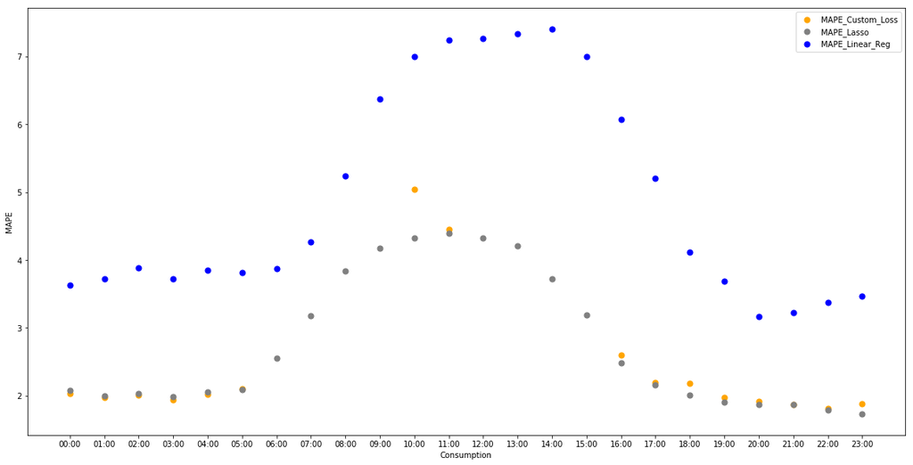

```python
import matplotlib.pyplot as plt


plt.figure(figsize=(20,10))
plt.scatter(combined_table['Hour'],combined_table['MAPE_Custom_Loss'],c='orange',s=50,label=('MAPE_Custom_Loss'))
plt.scatter(combined_table['Hour'],combined_table['MAPE_Lasso'],c='grey',s=50,label=('MAPE_Lasso'))
plt.scatter(combined_table['Hour'],combined_table['MAPE_Linear_Reg'],c='blue',s=50,label=('MAPE_Linear_Reg'))
plt.xlabel('Consumption')
plt.ylabel('MAPE')
plt.legend()
```

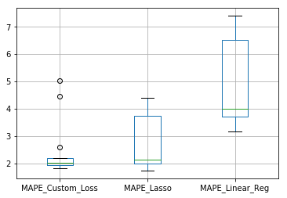

```python
combined_table[['MAPE_Custom_Loss','MAPE_Lasso','MAPE_Linear_Reg']].boxplot()
```

Linear regression model gives the worst performance. This is normal because there is multicollinearty between variables thus including all variable without any penalty is not logical. As a result it yielded worse compare to regularized versions. Between Lasso and Custom Loss (fussed penalties), we can not differentiate due to the problems mentioned 'Summary and Evaluation'.